# Risk Factor Analysis

## Outcome Variable

**Outcome Variable:** ever_wasted

## Predictor Variables

**Intervention Variable:** fage

**Adjustment Set:**

- arm
- W_mage
- meducyrs
- feducyrs
- W_mhtcm
- W_mwtkg
- W_mbmi
- W_fhtcm
- single
- brthmon
- delta_W_mage
- delta_meducyrs
- delta_feducyrs
- delta_W_mhtcm
- delta_W_mwtkg
- delta_W_mbmi
- delta_W_fhtcm
- delta_single
- delta_brthmon

## Stratifying Variables

The analysis was stratified on these variable(s):

- agecat
- studyid
- country

## Data Summary

| agecat | studyid | country | fage | ever_wasted | n_cell | n |
| --- | --- | --- | --- | --- | --- | --- |
| 0-24 months | ki0047075b-MAL-ED | BANGLADESH | >=38 | 0 | 46 | 151 |
| 0-24 months | ki0047075b-MAL-ED | BANGLADESH | >=38 | 1 | 23 | 151 |
| 0-24 months | ki0047075b-MAL-ED | BANGLADESH | <32 | 0 | 15 | 151 |
| 0-24 months | ki0047075b-MAL-ED | BANGLADESH | <32 | 1 | 15 | 151 |
| 0-24 months | ki0047075b-MAL-ED | BANGLADESH | [32-38) | 0 | 39 | 151 |
| 0-24 months | ki0047075b-MAL-ED | BANGLADESH | [32-38) | 1 | 13 | 151 |
| 0-24 months | ki0047075b-MAL-ED | BRAZIL | >=38 | 0 | 30 | 79 |
| 0-24 months | ki0047075b-MAL-ED | BRAZIL | >=38 | 1 | 0 | 79 |
| 0-24 months | ki0047075b-MAL-ED | BRAZIL | <32 | 0 | 16 | 79 |
| 0-24 months | ki0047075b-MAL-ED | BRAZIL | <32 | 1 | 2 | 79 |
| 0-24 months | ki0047075b-MAL-ED | BRAZIL | [32-38) | 0 | 28 | 79 |
| 0-24 months | ki0047075b-MAL-ED | BRAZIL | [32-38) | 1 | 3 | 79 |
| 0-24 months | ki0047075b-MAL-ED | INDIA | >=38 | 0 | 25 | 161 |
| 0-24 months | ki0047075b-MAL-ED | INDIA | >=38 | 1 | 11 | 161 |
| 0-24 months | ki0047075b-MAL-ED | INDIA | <32 | 0 | 20 | 161 |
| 0-24 months | ki0047075b-MAL-ED | INDIA | <32 | 1 | 33 | 161 |
| 0-24 months | ki0047075b-MAL-ED | INDIA | [32-38) | 0 | 36 | 161 |
| 0-24 months | ki0047075b-MAL-ED | INDIA | [32-38) | 1 | 36 | 161 |
| 0-24 months | ki0047075b-MAL-ED | NEPAL | >=38 | 0 | 13 | 79 |
| 0-24 months | ki0047075b-MAL-ED | NEPAL | >=38 | 1 | 4 | 79 |
| 0-24 months | ki0047075b-MAL-ED | NEPAL | <32 | 0 | 8 | 79 |
| 0-24 months | ki0047075b-MAL-ED | NEPAL | <32 | 1 | 7 | 79 |
| 0-24 months | ki0047075b-MAL-ED | NEPAL | [32-38) | 0 | 34 | 79 |
| 0-24 months | ki0047075b-MAL-ED | NEPAL | [32-38) | 1 | 13 | 79 |
| 0-24 months | ki0047075b-MAL-ED | PERU | >=38 | 0 | 26 | 85 |
| 0-24 months | ki0047075b-MAL-ED | PERU | >=38 | 1 | 1 | 85 |
| 0-24 months | ki0047075b-MAL-ED | PERU | <32 | 0 | 25 | 85 |
| 0-24 months | ki0047075b-MAL-ED | PERU | <32 | 1 | 4 | 85 |
| 0-24 months | ki0047075b-MAL-ED | PERU | [32-38) | 0 | 26 | 85 |
| 0-24 months | ki0047075b-MAL-ED | PERU | [32-38) | 1 | 3 | 85 |

[output cut: 204 more lines]

The following strata were considered:

- agecat: 0-24 months, studyid: ki0047075b-MAL-ED, country: BANGLADESH
- agecat: 0-24 months, studyid: ki0047075b-MAL-ED, country: BRAZIL
- agecat: 0-24 months, studyid: ki0047075b-MAL-ED, country: INDIA
- agecat: 0-24 months, studyid: ki0047075b-MAL-ED, country: NEPAL
- agecat: 0-24 months, studyid: ki0047075b-MAL-ED, country: PERU
- agecat: 0-24 months, studyid: ki0047075b-MAL-ED, country: SOUTH AFRICA
- agecat: 0-24 months, studyid: ki0047075b-MAL-ED, country: TANZANIA, UNITED REPUBLIC OF
- agecat: 0-24 months, studyid: ki1000304b-SAS-CompFeed, country: INDIA
- agecat: 0-24 months, studyid: ki1000304b-SAS-FoodSuppl, country: INDIA
- agecat: 0-24 months, studyid: ki1119695-PROBIT, country: BELARUS
- agecat: 0-24 months, studyid: ki1135781-COHORTS, country: GUATEMALA
- agecat: 0-24 months, studyid: ki1135781-COHORTS, country: PHILIPPINES
- agecat: 0-24 months, studyid: ki1148112-LCNI-5, country: MALAWI
- agecat: 0-6 months, studyid: ki0047075b-MAL-ED, country: BANGLADESH
- agecat: 0-6 months, studyid: ki0047075b-MAL-ED, country: BRAZIL
- agecat: 0-6 months, studyid: ki0047075b-MAL-ED, country: INDIA
- agecat: 0-6 months, studyid: ki0047075b-MAL-ED, country: NEPAL
- agecat: 0-6 months, studyid: ki0047075b-MAL-ED, country: PERU
- agecat: 0-6 months, studyid: ki0047075b-MAL-ED, country: SOUTH AFRICA
- agecat: 0-6 months, studyid: ki0047075b-MAL-ED, country: TANZANIA, UNITED REPUBLIC OF
- agecat: 0-6 months, studyid: ki1000304b-SAS-CompFeed, country: INDIA
- agecat: 0-6 months, studyid: ki1000304b-SAS-FoodSuppl, country: INDIA
- agecat: 0-6 months, studyid: ki1119695-PROBIT, country: BELARUS
- agecat: 0-6 months, studyid: ki1135781-COHORTS, country: GUATEMALA
- agecat: 0-6 months, studyid: ki1135781-COHORTS, country: PHILIPPINES
- agecat: 0-6 months, studyid: ki1148112-LCNI-5, country: MALAWI
- agecat: 6-24 months, studyid: ki0047075b-MAL-ED, country: BANGLADESH
- agecat: 6-24 months, studyid: ki0047075b-MAL-ED, country: BRAZIL
- agecat: 6-24 months, studyid: ki0047075b-MAL-ED, country: INDIA
- agecat: 6-24 months, studyid: ki0047075b-MAL-ED, country: NEPAL
- agecat: 6-24 months, studyid: ki0047075b-MAL-ED, country: PERU
- agecat: 6-24 months, studyid: ki0047075b-MAL-ED, country: SOUTH AFRICA
- agecat: 6-24 months, studyid: ki0047075b-MAL-ED, country: TANZANIA, UNITED REPUBLIC OF
- agecat: 6-24 months, studyid: ki1000304b-SAS-CompFeed, country: INDIA
- agecat: 6-24 months, studyid: ki1000304b-SAS-FoodSuppl, country: INDIA
- agecat: 6-24 months, studyid: ki1119695-PROBIT, country: BELARUS
- agecat: 6-24 months, studyid: ki1135781-COHORTS, country: GUATEMALA
- agecat: 6-24 months, studyid: ki1135781-COHORTS, country: PHILIPPINES
- agecat: 6-24 months, studyid: ki1148112-LCNI-5, country: MALAWI

### Dropped Strata

Some strata were dropped due to rare outcomes:

- agecat: 0-24 months, studyid: ki0047075b-MAL-ED, country: BRAZIL
- agecat: 0-24 months, studyid: ki0047075b-MAL-ED, country: NEPAL
- agecat: 0-24 months, studyid: ki0047075b-MAL-ED, country: PERU
- agecat: 0-24 months, studyid: ki0047075b-MAL-ED, country: SOUTH AFRICA
- agecat: 0-24 months, studyid: ki0047075b-MAL-ED, country: TANZANIA, UNITED REPUBLIC OF
- agecat: 0-24 months, studyid: ki1148112-LCNI-5, country: MALAWI
- agecat: 0-6 months, studyid: ki0047075b-MAL-ED, country: BRAZIL
- agecat: 0-6 months, studyid: ki0047075b-MAL-ED, country: NEPAL
- agecat: 0-6 months, studyid: ki0047075b-MAL-ED, country: PERU
- agecat: 0-6 months, studyid: ki0047075b-MAL-ED, country: SOUTH AFRICA
- agecat: 0-6 months, studyid: ki0047075b-MAL-ED, country: TANZANIA, UNITED REPUBLIC OF
- agecat: 0-6 months, studyid: ki1148112-LCNI-5, country: MALAWI
- agecat: 6-24 months, studyid: ki0047075b-MAL-ED, country: BRAZIL
- agecat: 6-24 months, studyid: ki0047075b-MAL-ED, country: NEPAL
- agecat: 6-24 months, studyid: ki0047075b-MAL-ED, country: PERU
- agecat: 6-24 months, studyid: ki0047075b-MAL-ED, country: SOUTH AFRICA
- agecat: 6-24 months, studyid: ki0047075b-MAL-ED, country: TANZANIA, UNITED REPUBLIC OF
- agecat: 6-24 months, studyid: ki1148112-LCNI-5, country: MALAWI

## Methods Detail

We’re interested in the causal parameters $E[Y_a]$ for all values of $a \in \mathcal{A}$. These parameters represent the mean outcome if, possibly contrary to fact, we intervened to set all units to have $A=a$. Under the randomization and positivity assumptions, these are identified by the statistical parameters $\psi_a=E_W[E_{Y|A,W}(Y|A=a,W)]$. In addition, we’re interested in the mean of $Y$, $E[Y]$ under no intervention (the observed mean). We will estimate these parameters by using SuperLearner to fit the relevant likelihood factors – $E_{Y|A,W}(Y|A=a,W)$ and $p(A=a|W)$, and then updating our likelihood fit using a joint TMLE.

For unadjusted analyses ($W=\{\}$), initial likelihoods were estimated using Lrnr_glm to estimate the simple $E(Y|A)$ and Lrnr_mean to estimate $p(A)$. For adjusted analyses, a small library containing Lrnr_glmnet, Lrnr_xgboost, and Lrnr_mean was used.

Having estimated these parameters, we will then use the delta method to estimate relative risks and attributable risks relative to a prespecified baseline level of $A$.

# Results Detail

## Results Plots

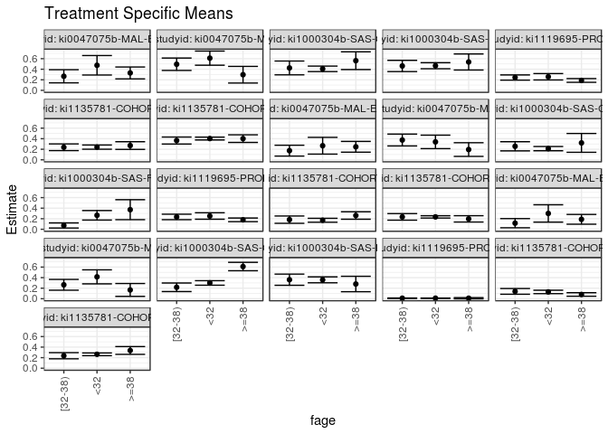

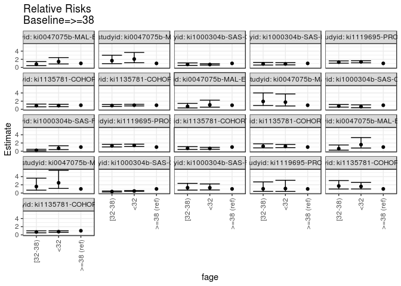

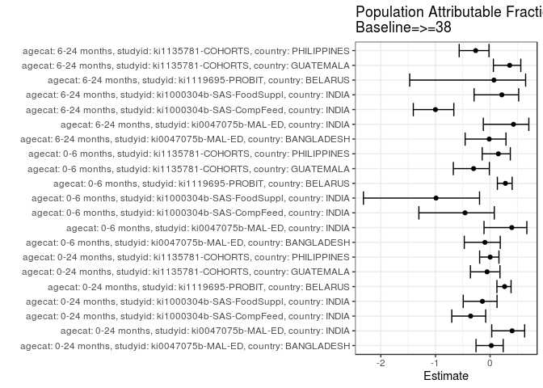

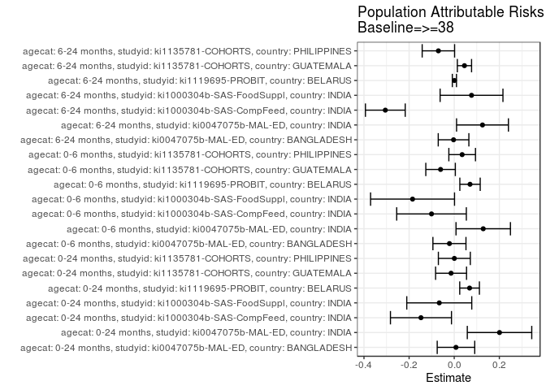

## Results Table

### Parameter: TSM

| agecat | studyid | country | intervention_level | baseline_level | estimate | ci_lower | ci_upper |
| --- | --- | --- | --- | --- | --- | --- | --- |
| 0-24 months | ki0047075b-MAL-ED | BANGLADESH | >=38 | NA | 0.3300165 | 0.2173240 | 0.4427090 |
| 0-24 months | ki0047075b-MAL-ED | BANGLADESH | <32 | NA | 0.4745832 | 0.2899170 | 0.6592495 |
| 0-24 months | ki0047075b-MAL-ED | BANGLADESH | [32-38) | NA | 0.2664591 | 0.1419202 | 0.3909979 |
| 0-24 months | ki0047075b-MAL-ED | INDIA | >=38 | NA | 0.2961413 | 0.1384319 | 0.4538508 |
| 0-24 months | ki0047075b-MAL-ED | INDIA | <32 | NA | 0.6102539 | 0.4759504 | 0.7445574 |
| 0-24 months | ki0047075b-MAL-ED | INDIA | [32-38) | NA | 0.4944913 | 0.3768964 | 0.6120863 |
| 0-24 months | ki1000304b-SAS-CompFeed | INDIA | >=38 | NA | 0.5619996 | 0.3937456 | 0.7302536 |
| 0-24 months | ki1000304b-SAS-CompFeed | INDIA | <32 | NA | 0.4072548 | 0.3554343 | 0.4590754 |
| 0-24 months | ki1000304b-SAS-CompFeed | INDIA | [32-38) | NA | 0.4244577 | 0.2937446 | 0.5551709 |
| 0-24 months | ki1000304b-SAS-FoodSuppl | INDIA | >=38 | NA | 0.5376231 | 0.3855188 | 0.6897273 |
| 0-24 months | ki1000304b-SAS-FoodSuppl | INDIA | <32 | NA | 0.4665428 | 0.4088801 | 0.5242056 |
| 0-24 months | ki1000304b-SAS-FoodSuppl | INDIA | [32-38) | NA | 0.4619329 | 0.3551121 | 0.5687538 |
| 0-24 months | ki1119695-PROBIT | BELARUS | >=38 | NA | 0.1874409 | 0.1520150 | 0.2228669 |
| 0-24 months | ki1119695-PROBIT | BELARUS | <32 | NA | 0.2571073 | 0.1962669 | 0.3179477 |
| 0-24 months | ki1119695-PROBIT | BELARUS | [32-38) | NA | 0.2426720 | 0.1932459 | 0.2920982 |
| 0-24 months | ki1135781-COHORTS | GUATEMALA | >=38 | NA | 0.2700550 | 0.1971192 | 0.3429909 |
| 0-24 months | ki1135781-COHORTS | GUATEMALA | <32 | NA | 0.2408190 | 0.2007598 | 0.2808782 |
| 0-24 months | ki1135781-COHORTS | GUATEMALA | [32-38) | NA | 0.2376078 | 0.1743271 | 0.3008886 |
| 0-24 months | ki1135781-COHORTS | PHILIPPINES | >=38 | NA | 0.4013197 | 0.3291396 | 0.4734999 |
| 0-24 months | ki1135781-COHORTS | PHILIPPINES | <32 | NA | 0.4029141 | 0.3758964 | 0.4299317 |
| 0-24 months | ki1135781-COHORTS | PHILIPPINES | [32-38) | NA | 0.3650524 | 0.2986800 | 0.4314248 |
| 0-6 months | ki0047075b-MAL-ED | BANGLADESH | >=38 | NA | 0.2463768 | 0.1443667 | 0.3483870 |
| 0-6 months | ki0047075b-MAL-ED | BANGLADESH | <32 | NA | 0.2666667 | 0.1078978 | 0.4254355 |
| 0-6 months | ki0047075b-MAL-ED | BANGLADESH | [32-38) | NA | 0.1730769 | 0.0699098 | 0.2762441 |
| 0-6 months | ki0047075b-MAL-ED | INDIA | >=38 | NA | 0.1944444 | 0.0647578 | 0.3241311 |
| 0-6 months | ki0047075b-MAL-ED | INDIA | <32 | NA | 0.3396226 | 0.2117265 | 0.4675188 |
| 0-6 months | ki0047075b-MAL-ED | INDIA | [32-38) | NA | 0.3750000 | 0.2628265 | 0.4871735 |
| 0-6 months | ki1000304b-SAS-CompFeed | INDIA | >=38 | NA | 0.3203655 | 0.1419059 | 0.4988251 |
| 0-6 months | ki1000304b-SAS-CompFeed | INDIA | <32 | NA | 0.2115571 | 0.1714884 | 0.2516257 |
| 0-6 months | ki1000304b-SAS-CompFeed | INDIA | [32-38) | NA | 0.2558912 | 0.1689365 | 0.3428459 |
| 0-6 months | ki1000304b-SAS-FoodSuppl | INDIA | >=38 | NA | 0.3713082 | 0.1818648 | 0.5607515 |
| 0-6 months | ki1000304b-SAS-FoodSuppl | INDIA | <32 | NA | 0.2648116 | 0.1749037 | 0.3547195 |
| 0-6 months | ki1000304b-SAS-FoodSuppl | INDIA | [32-38) | NA | 0.0721623 | 0.0236971 | 0.1206275 |
| 0-6 months | ki1119695-PROBIT | BELARUS | >=38 | NA | 0.1785430 | 0.1438667 | 0.2132193 |
| 0-6 months | ki1119695-PROBIT | BELARUS | <32 | NA | 0.2515383 | 0.1902682 | 0.3128083 |
| 0-6 months | ki1119695-PROBIT | BELARUS | [32-38) | NA | 0.2336519 | 0.1812886 | 0.2860151 |
| 0-6 months | ki1135781-COHORTS | GUATEMALA | >=38 | NA | 0.2611189 | 0.1901456 | 0.3320922 |
| 0-6 months | ki1135781-COHORTS | GUATEMALA | <32 | NA | 0.1708038 | 0.1337855 | 0.2078222 |
| 0-6 months | ki1135781-COHORTS | GUATEMALA | [32-38) | NA | 0.1824183 | 0.1132707 | 0.2515659 |
| 0-6 months | ki1135781-COHORTS | PHILIPPINES | >=38 | NA | 0.1969698 | 0.1369644 | 0.2569752 |
| 0-6 months | ki1135781-COHORTS | PHILIPPINES | <32 | NA | 0.2344257 | 0.2121793 | 0.2566722 |
| 0-6 months | ki1135781-COHORTS | PHILIPPINES | [32-38) | NA | 0.2347411 | 0.1726380 | 0.2968442 |
| 6-24 months | ki0047075b-MAL-ED | BANGLADESH | >=38 | NA | 0.1884058 | 0.0958331 | 0.2809785 |
| 6-24 months | ki0047075b-MAL-ED | BANGLADESH | <32 | NA | 0.3000000 | 0.1354719 | 0.4645281 |
| 6-24 months | ki0047075b-MAL-ED | BANGLADESH | [32-38) | NA | 0.1153846 | 0.0282601 | 0.2025091 |
| 6-24 months | ki0047075b-MAL-ED | INDIA | >=38 | NA | 0.1666667 | 0.0445476 | 0.2887858 |
| 6-24 months | ki0047075b-MAL-ED | INDIA | <32 | NA | 0.4150943 | 0.2820246 | 0.5481641 |
| 6-24 months | ki0047075b-MAL-ED | INDIA | [32-38) | NA | 0.2638889 | 0.1617674 | 0.3660104 |
| 6-24 months | ki1000304b-SAS-CompFeed | INDIA | >=38 | NA | 0.6106108 | 0.5309084 | 0.6903133 |
| 6-24 months | ki1000304b-SAS-CompFeed | INDIA | <32 | NA | 0.2996310 | 0.2567729 | 0.3424891 |
| 6-24 months | ki1000304b-SAS-CompFeed | INDIA | [32-38) | NA | 0.2170291 | 0.1357884 | 0.2982697 |
| 6-24 months | ki1000304b-SAS-FoodSuppl | INDIA | >=38 | NA | 0.2790270 | 0.1327376 | 0.4253165 |
| 6-24 months | ki1000304b-SAS-FoodSuppl | INDIA | <32 | NA | 0.3583802 | 0.3019401 | 0.4148203 |
| 6-24 months | ki1000304b-SAS-FoodSuppl | INDIA | [32-38) | NA | 0.3605761 | 0.2545668 | 0.4665853 |
| 6-24 months | ki1119695-PROBIT | BELARUS | >=38 | NA | 0.0095238 | -0.0012136 | 0.0202612 |
| 6-24 months | ki1119695-PROBIT | BELARUS | <32 | NA | 0.0103833 | 0.0077464 | 0.0130202 |
| 6-24 months | ki1119695-PROBIT | BELARUS | [32-38) | NA | 0.0098039 | 0.0053467 | 0.0142611 |
| 6-24 months | ki1135781-COHORTS | GUATEMALA | >=38 | NA | 0.0808604 | 0.0474238 | 0.1142971 |
| 6-24 months | ki1135781-COHORTS | GUATEMALA | <32 | NA | 0.1288812 | 0.0966111 | 0.1611513 |
| 6-24 months | ki1135781-COHORTS | GUATEMALA | [32-38) | NA | 0.1395130 | 0.0852427 | 0.1937832 |
| 6-24 months | ki1135781-COHORTS | PHILIPPINES | >=38 | NA | 0.3363669 | 0.2628415 | 0.4098922 |
| 6-24 months | ki1135781-COHORTS | PHILIPPINES | <32 | NA | 0.2635226 | 0.2378759 | 0.2891693 |
| 6-24 months | ki1135781-COHORTS | PHILIPPINES | [32-38) | NA | 0.2367021 | 0.1783316 | 0.2950726 |

### Parameter: E(Y)

| agecat | studyid | country | intervention_level | baseline_level | estimate | ci_lower | ci_upper |
| --- | --- | --- | --- | --- | --- | --- | --- |
| 0-24 months | ki0047075b-MAL-ED | BANGLADESH | NA | NA | 0.3377483 | 0.2620632 | 0.4134335 |
| 0-24 months | ki0047075b-MAL-ED | INDIA | NA | NA | 0.4968944 | 0.4194215 | 0.5743673 |
| 0-24 months | ki1000304b-SAS-CompFeed | INDIA | NA | NA | 0.4145695 | 0.3576236 | 0.4715155 |
| 0-24 months | ki1000304b-SAS-FoodSuppl | INDIA | NA | NA | 0.4712919 | 0.4233811 | 0.5192026 |
| 0-24 months | ki1119695-PROBIT | BELARUS | NA | NA | 0.2554368 | 0.1979772 | 0.3128964 |
| 0-24 months | ki1135781-COHORTS | GUATEMALA | NA | NA | 0.2560311 | 0.2321591 | 0.2799032 |
| 0-24 months | ki1135781-COHORTS | PHILIPPINES | NA | NA | 0.4018374 | 0.3841095 | 0.4195652 |
| 0-6 months | ki0047075b-MAL-ED | BANGLADESH | NA | NA | 0.2251656 | 0.1583223 | 0.2920089 |
| 0-6 months | ki0047075b-MAL-ED | INDIA | NA | NA | 0.3229814 | 0.2505249 | 0.3954378 |
| 0-6 months | ki1000304b-SAS-CompFeed | INDIA | NA | NA | 0.2197071 | 0.1750081 | 0.2644060 |
| 0-6 months | ki1000304b-SAS-FoodSuppl | INDIA | NA | NA | 0.1866029 | 0.1492099 | 0.2239959 |
| 0-6 months | ki1119695-PROBIT | BELARUS | NA | NA | 0.2485407 | 0.1903207 | 0.3067607 |
| 0-6 months | ki1135781-COHORTS | GUATEMALA | NA | NA | 0.2005842 | 0.1760818 | 0.2250867 |
| 0-6 months | ki1135781-COHORTS | PHILIPPINES | NA | NA | 0.2321307 | 0.2168619 | 0.2473995 |
| 6-24 months | ki0047075b-MAL-ED | BANGLADESH | NA | NA | 0.1854305 | 0.1232352 | 0.2476257 |
| 6-24 months | ki0047075b-MAL-ED | INDIA | NA | NA | 0.2919255 | 0.2214783 | 0.3623726 |
| 6-24 months | ki1000304b-SAS-CompFeed | INDIA | NA | NA | 0.3051948 | 0.2633957 | 0.3469939 |
| 6-24 months | ki1000304b-SAS-FoodSuppl | INDIA | NA | NA | 0.3557214 | 0.3088651 | 0.4025777 |
| 6-24 months | ki1119695-PROBIT | BELARUS | NA | NA | 0.0102551 | 0.0075905 | 0.0129198 |
| 6-24 months | ki1135781-COHORTS | GUATEMALA | NA | NA | 0.1261803 | 0.1071047 | 0.1452559 |
| 6-24 months | ki1135781-COHORTS | PHILIPPINES | NA | NA | 0.2661765 | 0.2495644 | 0.2827886 |

### Parameter: RR

| agecat | studyid | country | intervention_level | baseline_level | estimate | ci_lower | ci_upper |
| --- | --- | --- | --- | --- | --- | --- | --- |
| 0-24 months | ki0047075b-MAL-ED | BANGLADESH | >=38 | >=38 | 1.0000000 | 1.0000000 | 1.0000000 |
| 0-24 months | ki0047075b-MAL-ED | BANGLADESH | <32 | >=38 | 1.4380592 | 0.8558895 | 2.4162164 |
| 0-24 months | ki0047075b-MAL-ED | BANGLADESH | [32-38) | >=38 | 0.8074114 | 0.4535620 | 1.4373188 |
| 0-24 months | ki0047075b-MAL-ED | INDIA | >=38 | >=38 | 1.0000000 | 1.0000000 | 1.0000000 |
| 0-24 months | ki0047075b-MAL-ED | INDIA | <32 | >=38 | 2.0606846 | 1.1576909 | 3.6680094 |
| 0-24 months | ki0047075b-MAL-ED | INDIA | [32-38) | >=38 | 1.6697815 | 0.9303865 | 2.9967870 |
| 0-24 months | ki1000304b-SAS-CompFeed | INDIA | >=38 | >=38 | 1.0000000 | 1.0000000 | 1.0000000 |
| 0-24 months | ki1000304b-SAS-CompFeed | INDIA | <32 | >=38 | 0.7246533 | 0.5773474 | 0.9095430 |
| 0-24 months | ki1000304b-SAS-CompFeed | INDIA | [32-38) | >=38 | 0.7552635 | 0.5094567 | 1.1196691 |
| 0-24 months | ki1000304b-SAS-FoodSuppl | INDIA | >=38 | >=38 | 1.0000000 | 1.0000000 | 1.0000000 |
| 0-24 months | ki1000304b-SAS-FoodSuppl | INDIA | <32 | >=38 | 0.8677880 | 0.6371251 | 1.1819594 |
| 0-24 months | ki1000304b-SAS-FoodSuppl | INDIA | [32-38) | >=38 | 0.8592134 | 0.5960359 | 1.2385960 |
| 0-24 months | ki1119695-PROBIT | BELARUS | >=38 | >=38 | 1.0000000 | 1.0000000 | 1.0000000 |
| 0-24 months | ki1119695-PROBIT | BELARUS | <32 | >=38 | 1.3716711 | 1.1368602 | 1.6549807 |
| 0-24 months | ki1119695-PROBIT | BELARUS | [32-38) | >=38 | 1.2946588 | 1.0475482 | 1.6000612 |
| 0-24 months | ki1135781-COHORTS | GUATEMALA | >=38 | >=38 | 1.0000000 | 1.0000000 | 1.0000000 |
| 0-24 months | ki1135781-COHORTS | GUATEMALA | <32 | >=38 | 0.8917403 | 0.6500748 | 1.2232451 |
| 0-24 months | ki1135781-COHORTS | GUATEMALA | [32-38) | >=38 | 0.8798497 | 0.6026237 | 1.2846084 |
| 0-24 months | ki1135781-COHORTS | PHILIPPINES | >=38 | >=38 | 1.0000000 | 1.0000000 | 1.0000000 |
| 0-24 months | ki1135781-COHORTS | PHILIPPINES | <32 | >=38 | 1.0039727 | 0.8286086 | 1.2164503 |
| 0-24 months | ki1135781-COHORTS | PHILIPPINES | [32-38) | >=38 | 0.9096298 | 0.7043286 | 1.1747733 |
| 0-6 months | ki0047075b-MAL-ED | BANGLADESH | >=38 | >=38 | 1.0000000 | 1.0000000 | 1.0000000 |
| 0-6 months | ki0047075b-MAL-ED | BANGLADESH | <32 | >=38 | 1.0823529 | 0.5241066 | 2.2352092 |
| 0-6 months | ki0047075b-MAL-ED | BANGLADESH | [32-38) | >=38 | 0.7024887 | 0.3399717 | 1.4515632 |
| 0-6 months | ki0047075b-MAL-ED | INDIA | >=38 | >=38 | 1.0000000 | 1.0000000 | 1.0000000 |
| 0-6 months | ki0047075b-MAL-ED | INDIA | <32 | >=38 | 1.7466307 | 0.8120101 | 3.7569961 |
| 0-6 months | ki0047075b-MAL-ED | INDIA | [32-38) | >=38 | 1.9285714 | 0.9284968 | 4.0058164 |
| 0-6 months | ki1000304b-SAS-CompFeed | INDIA | >=38 | >=38 | 1.0000000 | 1.0000000 | 1.0000000 |
| 0-6 months | ki1000304b-SAS-CompFeed | INDIA | <32 | >=38 | 0.6603616 | 0.3987250 | 1.0936796 |
| 0-6 months | ki1000304b-SAS-CompFeed | INDIA | [32-38) | >=38 | 0.7987476 | 0.5424115 | 1.1762247 |
| 0-6 months | ki1000304b-SAS-FoodSuppl | INDIA | >=38 | >=38 | 1.0000000 | 1.0000000 | 1.0000000 |
| 0-6 months | ki1000304b-SAS-FoodSuppl | INDIA | <32 | >=38 | 0.7131855 | 0.3857275 | 1.3186344 |
| 0-6 months | ki1000304b-SAS-FoodSuppl | INDIA | [32-38) | >=38 | 0.1943461 | 0.0832715 | 0.4535812 |
| 0-6 months | ki1119695-PROBIT | BELARUS | >=38 | >=38 | 1.0000000 | 1.0000000 | 1.0000000 |
| 0-6 months | ki1119695-PROBIT | BELARUS | <32 | >=38 | 1.4088386 | 1.1584306 | 1.7133751 |
| 0-6 months | ki1119695-PROBIT | BELARUS | [32-38) | >=38 | 1.3086588 | 1.0347017 | 1.6551513 |
| 0-6 months | ki1135781-COHORTS | GUATEMALA | >=38 | >=38 | 1.0000000 | 1.0000000 | 1.0000000 |
| 0-6 months | ki1135781-COHORTS | GUATEMALA | <32 | >=38 | 0.6541229 | 0.4621824 | 0.9257746 |
| 0-6 months | ki1135781-COHORTS | GUATEMALA | [32-38) | >=38 | 0.6986026 | 0.4382975 | 1.1135031 |
| 0-6 months | ki1135781-COHORTS | PHILIPPINES | >=38 | >=38 | 1.0000000 | 1.0000000 | 1.0000000 |
| 0-6 months | ki1135781-COHORTS | PHILIPPINES | <32 | >=38 | 1.1901607 | 0.8650499 | 1.6374574 |
| 0-6 months | ki1135781-COHORTS | PHILIPPINES | [32-38) | >=38 | 1.1917619 | 0.7961065 | 1.7840532 |
| 6-24 months | ki0047075b-MAL-ED | BANGLADESH | >=38 | >=38 | 1.0000000 | 1.0000000 | 1.0000000 |
| 6-24 months | ki0047075b-MAL-ED | BANGLADESH | <32 | >=38 | 1.5923077 | 0.7624990 | 3.3251767 |
| 6-24 months | ki0047075b-MAL-ED | BANGLADESH | [32-38) | >=38 | 0.6124260 | 0.2487773 | 1.5076363 |
| 6-24 months | ki0047075b-MAL-ED | INDIA | >=38 | >=38 | 1.0000000 | 1.0000000 | 1.0000000 |
| 6-24 months | ki0047075b-MAL-ED | INDIA | <32 | >=38 | 2.4905660 | 1.1193351 | 5.5416104 |
| 6-24 months | ki0047075b-MAL-ED | INDIA | [32-38) | >=38 | 1.5833333 | 0.6913573 | 3.6261201 |
| 6-24 months | ki1000304b-SAS-CompFeed | INDIA | >=38 | >=38 | 1.0000000 | 1.0000000 | 1.0000000 |
| 6-24 months | ki1000304b-SAS-CompFeed | INDIA | <32 | >=38 | 0.4907070 | 0.3994595 | 0.6027980 |
| 6-24 months | ki1000304b-SAS-CompFeed | INDIA | [32-38) | >=38 | 0.3554294 | 0.2586265 | 0.4884653 |
| 6-24 months | ki1000304b-SAS-FoodSuppl | INDIA | >=38 | >=38 | 1.0000000 | 1.0000000 | 1.0000000 |
| 6-24 months | ki1000304b-SAS-FoodSuppl | INDIA | <32 | >=38 | 1.2843925 | 0.7420694 | 2.2230591 |
| 6-24 months | ki1000304b-SAS-FoodSuppl | INDIA | [32-38) | >=38 | 1.2922622 | 0.7076869 | 2.3597180 |
| 6-24 months | ki1119695-PROBIT | BELARUS | >=38 | >=38 | 1.0000000 | 1.0000000 | 1.0000000 |
| 6-24 months | ki1119695-PROBIT | BELARUS | <32 | >=38 | 1.0902490 | 0.3822067 | 3.1099478 |
| 6-24 months | ki1119695-PROBIT | BELARUS | [32-38) | >=38 | 1.0294118 | 0.3913001 | 2.7081224 |
| 6-24 months | ki1135781-COHORTS | GUATEMALA | >=38 | >=38 | 1.0000000 | 1.0000000 | 1.0000000 |
| 6-24 months | ki1135781-COHORTS | GUATEMALA | <32 | >=38 | 1.5938719 | 0.9833233 | 2.5835121 |
| 6-24 months | ki1135781-COHORTS | GUATEMALA | [32-38) | >=38 | 1.7253549 | 0.9785353 | 3.0421485 |
| 6-24 months | ki1135781-COHORTS | PHILIPPINES | >=38 | >=38 | 1.0000000 | 1.0000000 | 1.0000000 |
| 6-24 months | ki1135781-COHORTS | PHILIPPINES | <32 | >=38 | 0.7834381 | 0.6167108 | 0.9952400 |
| 6-24 months | ki1135781-COHORTS | PHILIPPINES | [32-38) | >=38 | 0.7037023 | 0.5061034 | 0.9784501 |

### Parameter: PAR

| agecat | studyid | country | intervention_level | baseline_level | estimate | ci_lower | ci_upper |
| --- | --- | --- | --- | --- | --- | --- | --- |
| 0-24 months | ki0047075b-MAL-ED | BANGLADESH | >=38 | NA | 0.0077319 | -0.0754191 | 0.0908828 |
| 0-24 months | ki0047075b-MAL-ED | INDIA | >=38 | NA | 0.2007531 | 0.0579278 | 0.3435783 |
| 0-24 months | ki1000304b-SAS-CompFeed | INDIA | >=38 | NA | -0.1474300 | -0.2826795 | -0.0121805 |
| 0-24 months | ki1000304b-SAS-FoodSuppl | INDIA | >=38 | NA | -0.0663312 | -0.2103436 | 0.0776813 |
| 0-24 months | ki1119695-PROBIT | BELARUS | >=38 | NA | 0.0679959 | 0.0243911 | 0.1116006 |
| 0-24 months | ki1135781-COHORTS | GUATEMALA | >=38 | NA | -0.0140239 | -0.0826018 | 0.0545541 |
| 0-24 months | ki1135781-COHORTS | PHILIPPINES | >=38 | NA | 0.0005176 | -0.0702521 | 0.0712874 |
| 0-6 months | ki0047075b-MAL-ED | BANGLADESH | >=38 | NA | -0.0212112 | -0.0944500 | 0.0520275 |
| 0-6 months | ki0047075b-MAL-ED | INDIA | >=38 | NA | 0.1285369 | 0.0079252 | 0.2491487 |
| 0-6 months | ki1000304b-SAS-CompFeed | INDIA | >=38 | NA | -0.1006585 | -0.2549842 | 0.0536672 |
| 0-6 months | ki1000304b-SAS-FoodSuppl | INDIA | >=38 | NA | -0.1847053 | -0.3707606 | 0.0013500 |
| 0-6 months | ki1119695-PROBIT | BELARUS | >=38 | NA | 0.0699977 | 0.0248611 | 0.1151343 |
| 0-6 months | ki1135781-COHORTS | GUATEMALA | >=38 | NA | -0.0605347 | -0.1259568 | 0.0048874 |
| 0-6 months | ki1135781-COHORTS | PHILIPPINES | >=38 | NA | 0.0351609 | -0.0238531 | 0.0941749 |
| 6-24 months | ki0047075b-MAL-ED | BANGLADESH | >=38 | NA | -0.0029753 | -0.0708431 | 0.0648925 |
| 6-24 months | ki0047075b-MAL-ED | INDIA | >=38 | NA | 0.1252588 | 0.0103385 | 0.2401791 |
| 6-24 months | ki1000304b-SAS-CompFeed | INDIA | >=38 | NA | -0.3054160 | -0.3935477 | -0.2172843 |
| 6-24 months | ki1000304b-SAS-FoodSuppl | INDIA | >=38 | NA | 0.0766944 | -0.0625532 | 0.2159419 |
| 6-24 months | ki1119695-PROBIT | BELARUS | >=38 | NA | 0.0007313 | -0.0085038 | 0.0099664 |
| 6-24 months | ki1135781-COHORTS | GUATEMALA | >=38 | NA | 0.0453198 | 0.0137767 | 0.0768629 |
| 6-24 months | ki1135781-COHORTS | PHILIPPINES | >=38 | NA | -0.0701904 | -0.1420415 | 0.0016608 |

### Parameter: PAF

| agecat | studyid | country | intervention_level | baseline_level | estimate | ci_lower | ci_upper |
| --- | --- | --- | --- | --- | --- | --- | --- |
| 0-24 months | ki0047075b-MAL-ED | BANGLADESH | >=38 | NA | 0.0228924 | -0.2571913 | 0.2405775 |
| 0-24 months | ki0047075b-MAL-ED | INDIA | >=38 | NA | 0.4040156 | 0.0305170 | 0.6336218 |
| 0-24 months | ki1000304b-SAS-CompFeed | INDIA | >=38 | NA | -0.3556220 | -0.7012932 | -0.0801847 |
| 0-24 months | ki1000304b-SAS-FoodSuppl | INDIA | >=38 | NA | -0.1407433 | -0.4914532 | 0.1274984 |
| 0-24 months | ki1119695-PROBIT | BELARUS | >=38 | NA | 0.2661944 | 0.1252599 | 0.3844222 |
| 0-24 months | ki1135781-COHORTS | GUATEMALA | >=38 | NA | -0.0547742 | -0.3596730 | 0.1817529 |
| 0-24 months | ki1135781-COHORTS | PHILIPPINES | >=38 | NA | 0.0012881 | -0.1913070 | 0.1627470 |
| 0-6 months | ki0047075b-MAL-ED | BANGLADESH | >=38 | NA | -0.0942029 | -0.4723931 | 0.1868476 |
| 0-6 months | ki0047075b-MAL-ED | INDIA | >=38 | NA | 0.3979701 | -0.1109883 | 0.6737679 |
| 0-6 months | ki1000304b-SAS-CompFeed | INDIA | >=38 | NA | -0.4581485 | -1.3037938 | 0.0770888 |
| 0-6 months | ki1000304b-SAS-FoodSuppl | INDIA | >=38 | NA | -0.9898309 | -2.3195660 | -0.1927544 |
| 0-6 months | ki1119695-PROBIT | BELARUS | >=38 | NA | 0.2816348 | 0.1337964 | 0.4042411 |
| 0-6 months | ki1135781-COHORTS | GUATEMALA | >=38 | NA | -0.3017918 | -0.6728058 | -0.0130655 |
| 0-6 months | ki1135781-COHORTS | PHILIPPINES | >=38 | NA | 0.1514703 | -0.1443520 | 0.3708206 |
| 6-24 months | ki0047075b-MAL-ED | BANGLADESH | >=38 | NA | -0.0160455 | -0.4566198 | 0.2912711 |
| 6-24 months | ki0047075b-MAL-ED | INDIA | >=38 | NA | 0.4290780 | -0.1233081 | 0.7098286 |
| 6-24 months | ki1000304b-SAS-CompFeed | INDIA | >=38 | NA | -1.0007249 | -1.4059186 | -0.6637721 |
| 6-24 months | ki1000304b-SAS-FoodSuppl | INDIA | >=38 | NA | 0.2156024 | -0.2930550 | 0.5241659 |
| 6-24 months | ki1119695-PROBIT | BELARUS | >=38 | NA | 0.0713124 | -1.4722970 | 0.6511501 |
| 6-24 months | ki1135781-COHORTS | GUATEMALA | >=38 | NA | 0.3591672 | 0.0608005 | 0.5627482 |
| 6-24 months | ki1135781-COHORTS | PHILIPPINES | >=38 | NA | -0.2636987 | -0.5655329 | -0.0200580 |